# MovieLens Project Questions

### `Project - MovieLens Data Analysis`

The GroupLens Research Project is a research group in the Department of Computer Science and Engineering at the University of Minnesota. The data is widely used for collaborative filtering and other filtering solutions. However, we will be using this data to act as a means to demonstrate our skill in using Python to “play” with data.

### `Objective:`

- To implement the techniques learnt as a part of the course.

### `Learning Outcomes:`

- Exploratory Data Analysis
- Visualization using Python
- Pandas – groupby, merging

### `Domain`

- Internet and Entertainment

**Note that the project will need you to apply the concepts of groupby and merging extensively.**

### `Datasets Information:`

*rating.csv:* It contains information on ratings given by the users to a particular movie.

- user id: id assigned to every user
- movie id: id assigned to every movie
- rating: rating given by the user
- timestamp: Time recorded when the user gave a rating

*movie.csv:* File contains information related to the movies and their genre.

- movie id: id assigned to every movie
- movie title: Title of the movie
- release date: Date of release of the movie
- Action: Genre containing binary values (1 - for action 0 - not action)
- Adventure: Genre containing binary values (1 - for adventure 0 - not adventure)
- Animation: Genre containing binary values (1 - for animation 0 - not animation)
- Children’s: Genre containing binary values (1 - for children's 0 - not children's)
- Comedy: Genre containing binary values (1 - for comedy 0 - not comedy)
- Crime: Genre containing binary values (1 - for crime 0 - not crime)
- Documentary: Genre containing binary values (1 - for documentary 0 - not documentary)
- Drama: Genre containing binary values (1 - for drama 0 - not drama)
- Fantasy: Genre containing binary values (1 - for fantasy 0 - not fantasy)
- Film-Noir: Genre containing binary values (1 - for film-noir 0 - not film-noir)
- Horror: Genre containing binary values (1 - for horror 0 - not horror)
- Musical: Genre containing binary values (1 - for musical 0 - not musical)
- Mystery: Genre containing binary values (1 - for mystery 0 - not mystery)
- Romance: Genre containing binary values (1 - for romance 0 - not romance)
- Sci-Fi: Genre containing binary values (1 - for sci-fi 0 - not sci-fi)
- Thriller: Genre containing binary values (1 - for thriller 0 - not thriller)
- War: Genre containing binary values (1 - for war 0 - not war)
- Western: Genre containing binary values (1 - for western - not western)

*user.csv:* It contains information of the users who have rated the movies.

- user id: id assigned to every user
- age: Age of the user
- gender: Gender of the user
- occupation: Occupation of the user
- zip code: Zip code of the use

**`Please provide you insights wherever necessary.`**

### 1. Import the necessary packages - 2.5 marks

```python
import pandas as pd
import seaborn as sns
from matplotlib import pyplot as plt
sns.set(color_codes=True)
import datetime
%matplotlib inline
```

### 2. Read the 3 datasets into dataframes - 2.5 marks

```python
user_ratings = pd.read_csv('/Users/vishnunair/Desktop/PGP AIML Data/Data (1).csv')
movie_data = pd.read_csv('/Users/vishnunair/Desktop/PGP AIML Data/item.csv')
user_data = pd.read_csv('/Users/vishnunair/Desktop/PGP AIML Data/user.csv')
```

### 3. Apply info, shape, describe, and find the number of missing values in the data - 5 marks

- Note that you will need to do it for all the three datasets seperately

```python
#There are 4 columns with 100,000 values each in this dataset
user_ratings.info()
```

```
<class 'pandas.core.frame.DataFrame'>
RangeIndex: 100000 entries, 0 to 99999
Data columns (total 4 columns):
 #   Column     Non-Null Count   Dtype
---  ------     --------------   -----
 0   user id    100000 non-null  int64
 1   movie id   100000 non-null  int64
 2   rating     100000 non-null  int64
 3   timestamp  100000 non-null  int64
dtypes: int64(4)
memory usage: 3.1 MB
```

```python
user_ratings.shape
```

```
(100000, 4)
```

```python
user_ratings.describe()
```

|  | user id | movie id | rating | timestamp |
| --- | --- | --- | --- | --- |
| count | 100000.00000 | 100000.000000 | 100000.000000 | 1.000000e+05 |
| mean | 462.48475 | 425.530130 | 3.529860 | 8.835289e+08 |
| std | 266.61442 | 330.798356 | 1.125674 | 5.343856e+06 |
| min | 1.00000 | 1.000000 | 1.000000 | 8.747247e+08 |
| 25% | 254.00000 | 175.000000 | 3.000000 | 8.794487e+08 |
| 50% | 447.00000 | 322.000000 | 4.000000 | 8.828269e+08 |
| 75% | 682.00000 | 631.000000 | 4.000000 | 8.882600e+08 |
| max | 943.00000 | 1682.000000 | 5.000000 | 8.932866e+08 |

```python
#There are no null values in this dataset
user_ratings.isnull().sum()
```

```
user id      0
movie id     0
rating       0
timestamp    0
dtype: int64
```

```python
#There are 22 columns with 1,681 values each in this dataset
movie_data.info()
```

```
<class 'pandas.core.frame.DataFrame'>
RangeIndex: 1681 entries, 0 to 1680
Data columns (total 22 columns):
 #   Column        Non-Null Count  Dtype
---  ------        --------------  -----
 0   movie id      1681 non-null   int64
 1   movie title   1681 non-null   object
 2   release date  1681 non-null   object
 3   unknown       1681 non-null   int64
 4   Action        1681 non-null   int64
 5   Adventure     1681 non-null   int64
 6   Animation     1681 non-null   int64
 7   Childrens     1681 non-null   int64
 8   Comedy        1681 non-null   int64
 9   Crime         1681 non-null   int64
 10  Documentary   1681 non-null   int64
 11  Drama         1681 non-null   int64
 12  Fantasy       1681 non-null   int64
 13  Film-Noir     1681 non-null   int64
 14  Horror        1681 non-null   int64
 15  Musical       1681 non-null   int64
 16  Mystery       1681 non-null   int64
 17  Romance       1681 non-null   int64
 18  Sci-Fi        1681 non-null   int64
 19  Thriller      1681 non-null   int64
 20  War           1681 non-null   int64
 21  Western       1681 non-null   int64
dtypes: int64(20), object(2)
memory usage: 289.0+ KB
```

```python
movie_data.shape
```

```
(1681, 22)
```

```python
movie_data.describe()
```

|  | movie id | unknown | Action | Adventure | Animation | Childrens | Comedy | Crime | Documentary | Drama | Fantasy | Film-Noir | Horror | Musical | Mystery | Romance | Sci-Fi | Thriller | War | Western |
| --- | --- | --- | --- | --- | --- | --- | --- | --- | --- | --- | --- | --- | --- | --- | --- | --- | --- | --- | --- | --- |
| count | 1681.000000 | 1681.000000 | 1681.000000 | 1681.000000 | 1681.000000 | 1681.000000 | 1681.000000 | 1681.000000 | 1681.000000 | 1681.000000 | 1681.000000 | 1681.000000 | 1681.000000 | 1681.000000 | 1681.000000 | 1681.000000 | 1681.000000 | 1681.000000 | 1681.000000 | 1681.000000 |
| mean | 841.841761 | 0.000595 | 0.149316 | 0.080309 | 0.024985 | 0.072576 | 0.300416 | 0.064842 | 0.029744 | 0.431291 | 0.013087 | 0.014277 | 0.054729 | 0.033314 | 0.036288 | 0.146936 | 0.060083 | 0.149316 | 0.042237 | 0.016062 |
| std | 485.638077 | 0.024390 | 0.356506 | 0.271852 | 0.156126 | 0.259516 | 0.458576 | 0.246321 | 0.169931 | 0.495404 | 0.113683 | 0.118667 | 0.227519 | 0.179507 | 0.187061 | 0.354148 | 0.237712 | 0.356506 | 0.201189 | 0.125751 |
| min | 1.000000 | 0.000000 | 0.000000 | 0.000000 | 0.000000 | 0.000000 | 0.000000 | 0.000000 | 0.000000 | 0.000000 | 0.000000 | 0.000000 | 0.000000 | 0.000000 | 0.000000 | 0.000000 | 0.000000 | 0.000000 | 0.000000 | 0.000000 |
| 25% | 422.000000 | 0.000000 | 0.000000 | 0.000000 | 0.000000 | 0.000000 | 0.000000 | 0.000000 | 0.000000 | 0.000000 | 0.000000 | 0.000000 | 0.000000 | 0.000000 | 0.000000 | 0.000000 | 0.000000 | 0.000000 | 0.000000 | 0.000000 |
| 50% | 842.000000 | 0.000000 | 0.000000 | 0.000000 | 0.000000 | 0.000000 | 0.000000 | 0.000000 | 0.000000 | 0.000000 | 0.000000 | 0.000000 | 0.000000 | 0.000000 | 0.000000 | 0.000000 | 0.000000 | 0.000000 | 0.000000 | 0.000000 |
| 75% | 1262.000000 | 0.000000 | 0.000000 | 0.000000 | 0.000000 | 0.000000 | 1.000000 | 0.000000 | 0.000000 | 1.000000 | 0.000000 | 0.000000 | 0.000000 | 0.000000 | 0.000000 | 0.000000 | 0.000000 | 0.000000 | 0.000000 | 0.000000 |
| max | 1682.000000 | 1.000000 | 1.000000 | 1.000000 | 1.000000 | 1.000000 | 1.000000 | 1.000000 | 1.000000 | 1.000000 | 1.000000 | 1.000000 | 1.000000 | 1.000000 | 1.000000 | 1.000000 | 1.000000 | 1.000000 | 1.000000 | 1.000000 |

```python
#There are no missing values in the dataset
movie_data.isnull().sum()
```

```
movie id        0
movie title     0
release date    0
unknown         0
Action          0
Adventure       0
Animation       0
Childrens       0
Comedy          0
Crime           0
Documentary     0
Drama           0
Fantasy         0
Film-Noir       0
Horror          0
Musical         0
Mystery         0
Romance         0
Sci-Fi          0
Thriller        0
War             0
Western         0
dtype: int64
```

```python
#There are 5 columns with 943 values each in this dataset
user_data.info()
```

```
<class 'pandas.core.frame.DataFrame'>
RangeIndex: 943 entries, 0 to 942
Data columns (total 5 columns):
 #   Column      Non-Null Count  Dtype
---  ------      --------------  -----
 0   user id     943 non-null    int64
 1   age         943 non-null    int64
 2   gender      943 non-null    object
 3   occupation  943 non-null    object
 4   zip code    943 non-null    object
dtypes: int64(2), object(3)
memory usage: 37.0+ KB
```

```python
user_data.shape
```

```
(943, 5)
```

```python
user_data.describe()
```

|  | user id | age |
| --- | --- | --- |
| count | 943.000000 | 943.000000 |
| mean | 472.000000 | 34.051962 |
| std | 272.364951 | 12.192740 |
| min | 1.000000 | 7.000000 |
| 25% | 236.500000 | 25.000000 |
| 50% | 472.000000 | 31.000000 |
| 75% | 707.500000 | 43.000000 |
| max | 943.000000 | 73.000000 |

```python
#There are no missing values in this dataset
user_data.isnull().sum()
```

```
user id       0
age           0
gender        0
occupation    0
zip code      0
dtype: int64
```

### 4. Find the number of movies per genre using the item data - 2.5 marks

```python
movie_data.iloc[:,3:].sum()
```

```
unknown          1
Action         251
Adventure      135
Animation       42
Childrens      122
Comedy         505
Crime          109
Documentary     50
Drama          725
Fantasy         22
Film-Noir       24
Horror          92
Musical         56
Mystery         61
Romance        247
Sci-Fi         101
Thriller       251
War             71
Western         27
dtype: int64
```

```python
movie_data.shape
```

```
(1681, 22)
```

### 5. Drop the movie where the genre is unknown - 2.5 marks

```python
#By running the commented code, we note that querying for movies with unknown genre returns an empty dataset,
    #indicating that the unknown genre movie has been dropped
new_movie_data = movie_data[movie_data['unknown'] == 0]
#new_movie_data[new_movie_data['unknown'] == 1]
```

### 6. Find the movies that have more than one genre - 5 marks

hint: use sum on the axis = 1

Display movie name, number of genres for the movie in dataframe

and also print(total number of movies which have more than one genres)

```python
#Isolating just the movie genres portion of the dataset
genres= movie_data.iloc[:,3:]
genres.head()
```

|  | unknown | Action | Adventure | Animation | Childrens | Comedy | Crime | Documentary | Drama | Fantasy | Film-Noir | Horror | Musical | Mystery | Romance | Sci-Fi | Thriller | War | Western |
| --- | --- | --- | --- | --- | --- | --- | --- | --- | --- | --- | --- | --- | --- | --- | --- | --- | --- | --- | --- |
| 0 | 0 | 0 | 0 | 1 | 1 | 1 | 0 | 0 | 0 | 0 | 0 | 0 | 0 | 0 | 0 | 0 | 0 | 0 | 0 |
| 1 | 0 | 1 | 1 | 0 | 0 | 0 | 0 | 0 | 0 | 0 | 0 | 0 | 0 | 0 | 0 | 0 | 1 | 0 | 0 |
| 2 | 0 | 0 | 0 | 0 | 0 | 0 | 0 | 0 | 0 | 0 | 0 | 0 | 0 | 0 | 0 | 0 | 1 | 0 | 0 |
| 3 | 0 | 1 | 0 | 0 | 0 | 1 | 0 | 0 | 1 | 0 | 0 | 0 | 0 | 0 | 0 | 0 | 0 | 0 | 0 |
| 4 | 0 | 0 | 0 | 0 | 0 | 0 | 1 | 0 | 1 | 0 | 0 | 0 | 0 | 0 | 0 | 0 | 1 | 0 | 0 |

```python
#Adding back the 'movie title' column
genres = genres.join(movie_data['movie title'])
genres = genres.set_index('movie title')
genres.head()
```

| movie title | unknown | Action | Adventure | Animation | Childrens | Comedy | Crime | Documentary | Drama | Fantasy | Film-Noir | Horror | Musical | Mystery | Romance | Sci-Fi | Thriller | War | Western |
| --- | --- | --- | --- | --- | --- | --- | --- | --- | --- | --- | --- | --- | --- | --- | --- | --- | --- | --- | --- |
| Toy Story | 0 | 0 | 0 | 1 | 1 | 1 | 0 | 0 | 0 | 0 | 0 | 0 | 0 | 0 | 0 | 0 | 0 | 0 | 0 |
| GoldenEye | 0 | 1 | 1 | 0 | 0 | 0 | 0 | 0 | 0 | 0 | 0 | 0 | 0 | 0 | 0 | 0 | 1 | 0 | 0 |
| Four Rooms | 0 | 0 | 0 | 0 | 0 | 0 | 0 | 0 | 0 | 0 | 0 | 0 | 0 | 0 | 0 | 0 | 1 | 0 | 0 |
| Get Shorty | 0 | 1 | 0 | 0 | 0 | 1 | 0 | 0 | 1 | 0 | 0 | 0 | 0 | 0 | 0 | 0 | 0 | 0 | 0 |
| Copycat | 0 | 0 | 0 | 0 | 0 | 0 | 1 | 0 | 1 | 0 | 0 | 0 | 0 | 0 | 0 | 0 | 1 | 0 | 0 |

```python
#Summing along the rows and finding movies that have more than one genre
genres['Num of Genres'] = genres.sum(axis=1)
multiple_genres = genres[genres['Num of Genres'] > 1]
multiple_genres
```

| movie title | unknown | Action | Adventure | Animation | Childrens | Comedy | Crime | Documentary | Drama | Fantasy | Film-Noir | Horror | Musical | Mystery | Romance | Sci-Fi | Thriller | War | Western | Num of Genres |
| --- | --- | --- | --- | --- | --- | --- | --- | --- | --- | --- | --- | --- | --- | --- | --- | --- | --- | --- | --- | --- |
| Toy Story | 0 | 0 | 0 | 1 | 1 | 1 | 0 | 0 | 0 | 0 | 0 | 0 | 0 | 0 | 0 | 0 | 0 | 0 | 0 | 3 |
| GoldenEye | 0 | 1 | 1 | 0 | 0 | 0 | 0 | 0 | 0 | 0 | 0 | 0 | 0 | 0 | 0 | 0 | 1 | 0 | 0 | 3 |
| Get Shorty | 0 | 1 | 0 | 0 | 0 | 1 | 0 | 0 | 1 | 0 | 0 | 0 | 0 | 0 | 0 | 0 | 0 | 0 | 0 | 3 |
| Copycat | 0 | 0 | 0 | 0 | 0 | 0 | 1 | 0 | 1 | 0 | 0 | 0 | 0 | 0 | 0 | 0 | 1 | 0 | 0 | 3 |
| Twelve Monkeys | 0 | 0 | 0 | 0 | 0 | 0 | 0 | 0 | 1 | 0 | 0 | 0 | 0 | 0 | 0 | 1 | 0 | 0 | 0 | 2 |
| ... | ... | ... | ... | ... | ... | ... | ... | ... | ... | ... | ... | ... | ... | ... | ... | ... | ... | ... | ... | ... |
| MURDER and murder | 0 | 0 | 0 | 0 | 0 | 0 | 1 | 0 | 1 | 0 | 0 | 0 | 0 | 1 | 0 | 0 | 0 | 0 | 0 | 3 |
| Tainted | 0 | 0 | 0 | 0 | 0 | 1 | 0 | 0 | 0 | 0 | 0 | 0 | 0 | 0 | 0 | 0 | 1 | 0 | 0 | 2 |
| Mirage | 0 | 1 | 0 | 0 | 0 | 0 | 0 | 0 | 0 | 0 | 0 | 0 | 0 | 0 | 0 | 0 | 1 | 0 | 0 | 2 |
| B. Monkey | 0 | 0 | 0 | 0 | 0 | 0 | 0 | 0 | 0 | 0 | 0 | 0 | 0 | 0 | 1 | 0 | 1 | 0 | 0 | 2 |
| Sliding Doors | 0 | 0 | 0 | 0 | 0 | 0 | 0 | 0 | 1 | 0 | 0 | 0 | 0 | 0 | 1 | 0 | 0 | 0 | 0 | 2 |

849 rows × 20 columns

```python
# Movie name and number of genres in a dataframe
result = pd.DataFrame(multiple_genres['Num of Genres'])
result = result.reset_index()
result
```

|  | movie title | Num of Genres |
| --- | --- | --- |
| 0 | Toy Story | 3 |
| 1 | GoldenEye | 3 |
| 2 | Get Shorty | 3 |
| 3 | Copycat | 3 |
| 4 | Twelve Monkeys | 2 |
| ... | ... | ... |
| 844 | MURDER and murder | 3 |
| 845 | Tainted | 2 |
| 846 | Mirage | 2 |
| 847 | B. Monkey | 2 |
| 848 | Sliding Doors | 2 |

849 rows × 2 columns

```python
#Using groupby, we note that the length of this dataframe is less than 'result'. This means that there
    # are duplicate movie names.
# Hence, there are 838 movies that have multiple genres
len(result.groupby('movie title'))
```

```
838
```

### 7. Univariate plots of columns: 'rating', 'Age', 'release year', 'Gender' and 'Occupation' - 10 marks

*HINT: Use distplot for age. Use lineplot or countplot for release year.*

*HINT: Plot percentages in y-axis and categories in x-axis for ratings, gender and occupation*

*HINT: Please refer to the below snippet to understand how to get to release year from release date. You can use str.split() as depicted below or you could convert it to pandas datetime format and extract year (.dt.year)*

```python
a = 'My*cat*is*brown'
print(a.split('*')[3])

#similarly, the release year needs to be taken out from release date

#also you can simply slice existing string to get the desired data, if we want to take out the colour of the cat

print(a[10:])
print(a[-5:])
```

```
brown
brown
brown
```

```python
user_ratings.head()
```

|  | user id | movie id | rating | timestamp |
| --- | --- | --- | --- | --- |
| 0 | 196 | 242 | 3 | 881250949 |
| 1 | 186 | 302 | 3 | 891717742 |
| 2 | 22 | 377 | 1 | 878887116 |
| 3 | 244 | 51 | 2 | 880606923 |
| 4 | 166 | 346 | 1 | 886397596 |

```python
user_data.head()
```

|  | user id | age | gender | occupation | zip code |
| --- | --- | --- | --- | --- | --- |
| 0 | 1 | 24 | M | technician | 85711 |
| 1 | 2 | 53 | F | other | 94043 |
| 2 | 3 | 23 | M | writer | 32067 |
| 3 | 4 | 24 | M | technician | 43537 |
| 4 | 5 | 33 | F | other | 15213 |

```python
full_user_data = pd.merge(user_ratings, user_data, on='user id')
full_user_data.head()
```

|  | user id | movie id | rating | timestamp | age | gender | occupation | zip code |
| --- | --- | --- | --- | --- | --- | --- | --- | --- |
| 0 | 196 | 242 | 3 | 881250949 | 49 | M | writer | 55105 |
| 1 | 196 | 393 | 4 | 881251863 | 49 | M | writer | 55105 |
| 2 | 196 | 381 | 4 | 881251728 | 49 | M | writer | 55105 |
| 3 | 196 | 251 | 3 | 881251274 | 49 | M | writer | 55105 |
| 4 | 196 | 655 | 5 | 881251793 | 49 | M | writer | 55105 |

```python
complete_data = pd.merge(full_user_data, movie_data, on='movie id')
complete_data.head()
```

|  | user id | movie id | rating | timestamp | age | gender | occupation | zip code | movie title | release date | ... | Fantasy | Film-Noir | Horror | Musical | Mystery | Romance | Sci-Fi | Thriller | War | Western |
| --- | --- | --- | --- | --- | --- | --- | --- | --- | --- | --- | --- | --- | --- | --- | --- | --- | --- | --- | --- | --- | --- |
| 0 | 196 | 242 | 3 | 881250949 | 49 | M | writer | 55105 | Kolya | 24-Jan-1997 | ... | 0 | 0 | 0 | 0 | 0 | 0 | 0 | 0 | 0 | 0 |
| 1 | 305 | 242 | 5 | 886307828 | 23 | M | programmer | 94086 | Kolya | 24-Jan-1997 | ... | 0 | 0 | 0 | 0 | 0 | 0 | 0 | 0 | 0 | 0 |
| 2 | 6 | 242 | 4 | 883268170 | 42 | M | executive | 98101 | Kolya | 24-Jan-1997 | ... | 0 | 0 | 0 | 0 | 0 | 0 | 0 | 0 | 0 | 0 |
| 3 | 234 | 242 | 4 | 891033261 | 60 | M | retired | 94702 | Kolya | 24-Jan-1997 | ... | 0 | 0 | 0 | 0 | 0 | 0 | 0 | 0 | 0 | 0 |
| 4 | 63 | 242 | 3 | 875747190 | 31 | M | marketing | 75240 | Kolya | 24-Jan-1997 | ... | 0 | 0 | 0 | 0 | 0 | 0 | 0 | 0 | 0 | 0 |

5 rows × 29 columns

```python
complete_data['Release Year'] = pd.DatetimeIndex(complete_data['release date']).year
complete_data.head()
```

|  | user id | movie id | rating | timestamp | age | gender | occupation | zip code | movie title | release date | ... | Film-Noir | Horror | Musical | Mystery | Romance | Sci-Fi | Thriller | War | Western | Release Year |
| --- | --- | --- | --- | --- | --- | --- | --- | --- | --- | --- | --- | --- | --- | --- | --- | --- | --- | --- | --- | --- | --- |
| 0 | 196 | 242 | 3 | 881250949 | 49 | M | writer | 55105 | Kolya | 24-Jan-1997 | ... | 0 | 0 | 0 | 0 | 0 | 0 | 0 | 0 | 0 | 1997 |
| 1 | 305 | 242 | 5 | 886307828 | 23 | M | programmer | 94086 | Kolya | 24-Jan-1997 | ... | 0 | 0 | 0 | 0 | 0 | 0 | 0 | 0 | 0 | 1997 |
| 2 | 6 | 242 | 4 | 883268170 | 42 | M | executive | 98101 | Kolya | 24-Jan-1997 | ... | 0 | 0 | 0 | 0 | 0 | 0 | 0 | 0 | 0 | 1997 |
| 3 | 234 | 242 | 4 | 891033261 | 60 | M | retired | 94702 | Kolya | 24-Jan-1997 | ... | 0 | 0 | 0 | 0 | 0 | 0 | 0 | 0 | 0 | 1997 |
| 4 | 63 | 242 | 3 | 875747190 | 31 | M | marketing | 75240 | Kolya | 24-Jan-1997 | ... | 0 | 0 | 0 | 0 | 0 | 0 | 0 | 0 | 0 | 1997 |

5 rows × 30 columns

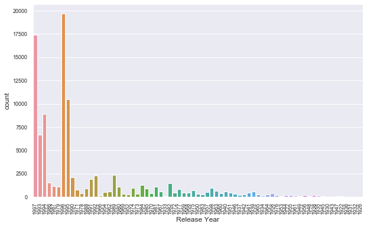

```python
complete_data['Release Year'] = complete_data['Release Year'].astype(str)
fig_dims = (10, 6)
fig, ax = plt.subplots(figsize=fig_dims)
plot = sns.countplot(complete_data['Release Year'], ax=ax)
plot.set_xticklabels(plot.get_xticklabels(), rotation=90)
plot.tick_params(labelsize=9)
plot
```

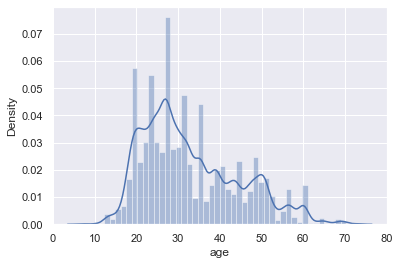

```python
sns.distplot(full_user_data['age'])
```

```python
user_date = pd.merge(user_ratings, user_data, on='user id')
```

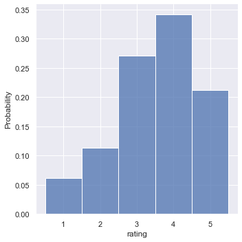

```python
sns.displot(data= full_user_data, x='rating', stat= 'probability',discrete=True)
```

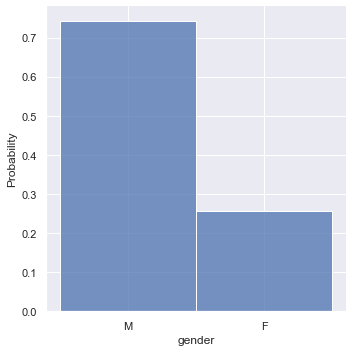

```python
sns.displot(data= full_user_data, x='gender', stat= 'probability',discrete=True)
```

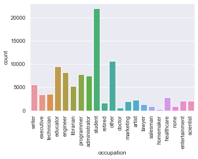

```python
plot = sns.countplot(full_user_data['occupation'], orient="v")
plot.set_xticklabels(plot.get_xticklabels(), rotation=90)
plot
```

### 8. Visualize how popularity of genres has changed over the years - 10 marks

Note that you need to use the **percent of number of releases in a year** as a parameter of popularity of a genre

Hint 1: You need to reach to a data frame where the release year is the index and the genre is the column names (one cell shows the number of release in a year in one genre) or vice versa. (Drop unnecessary column if there are any)

Hint 2: Find the total number of movies release in a year(use `sum(axis=1)` store that value in a new column as 'total'). Now divide the value of each genre in that year by total to get percentage number of release in a particular year. `(df.div(df['total'], axis= 0) * 100)`

Once that is achieved, you can either use univariate plots or can use the heatmap to visualise all the changes over the years in one go.

Hint 3: Use groupby on the relevant column and use sum() on the same to find out the number of releases in a year/genre.

```python
complete_data.head()
```

|  | user id | movie id | rating | timestamp | age | gender | occupation | zip code | movie title | release date | ... | Film-Noir | Horror | Musical | Mystery | Romance | Sci-Fi | Thriller | War | Western | Release Year |
| --- | --- | --- | --- | --- | --- | --- | --- | --- | --- | --- | --- | --- | --- | --- | --- | --- | --- | --- | --- | --- | --- |
| 0 | 196 | 242 | 3 | 881250949 | 49 | M | writer | 55105 | Kolya | 24-Jan-1997 | ... | 0 | 0 | 0 | 0 | 0 | 0 | 0 | 0 | 0 | 1997 |
| 1 | 305 | 242 | 5 | 886307828 | 23 | M | programmer | 94086 | Kolya | 24-Jan-1997 | ... | 0 | 0 | 0 | 0 | 0 | 0 | 0 | 0 | 0 | 1997 |
| 2 | 6 | 242 | 4 | 883268170 | 42 | M | executive | 98101 | Kolya | 24-Jan-1997 | ... | 0 | 0 | 0 | 0 | 0 | 0 | 0 | 0 | 0 | 1997 |
| 3 | 234 | 242 | 4 | 891033261 | 60 | M | retired | 94702 | Kolya | 24-Jan-1997 | ... | 0 | 0 | 0 | 0 | 0 | 0 | 0 | 0 | 0 | 1997 |
| 4 | 63 | 242 | 3 | 875747190 | 31 | M | marketing | 75240 | Kolya | 24-Jan-1997 | ... | 0 | 0 | 0 | 0 | 0 | 0 | 0 | 0 | 0 | 1997 |

5 rows × 30 columns

```python
annual_data = complete_data.groupby('Release Year').sum()
annual_data = annual_data.iloc[:,5:]
annual_data
```

| Release Year | unknown | Action | Adventure | Animation | Childrens | Comedy | Crime | Documentary | Drama | Fantasy | Film-Noir | Horror | Musical | Mystery | Romance | Sci-Fi | Thriller | War | Western |
| --- | --- | --- | --- | --- | --- | --- | --- | --- | --- | --- | --- | --- | --- | --- | --- | --- | --- | --- | --- |
| 1922 | 0 | 0 | 0 | 0 | 0 | 0 | 0 | 0 | 0 | 0 | 0 | 54 | 0 | 0 | 0 | 0 | 0 | 0 | 0 |
| 1926 | 0 | 0 | 0 | 0 | 0 | 0 | 0 | 0 | 2 | 0 | 0 | 0 | 0 | 0 | 0 | 0 | 0 | 0 | 0 |
| 1930 | 0 | 0 | 0 | 0 | 0 | 0 | 0 | 0 | 18 | 0 | 0 | 0 | 0 | 0 | 0 | 0 | 0 | 0 | 0 |
| 1931 | 0 | 0 | 0 | 0 | 0 | 0 | 44 | 0 | 0 | 0 | 44 | 0 | 0 | 0 | 0 | 0 | 44 | 0 | 0 |
| 1932 | 0 | 0 | 0 | 0 | 0 | 0 | 0 | 0 | 0 | 0 | 0 | 0 | 0 | 0 | 12 | 0 | 0 | 12 | 0 |
| ... | ... | ... | ... | ... | ... | ... | ... | ... | ... | ... | ... | ... | ... | ... | ... | ... | ... | ... | ... |
| 1994 | 0 | 1741 | 878 | 244 | 605 | 3524 | 784 | 222 | 3787 | 211 | 0 | 375 | 237 | 109 | 2367 | 358 | 1521 | 499 | 319 |
| 1995 | 0 | 2328 | 1018 | 550 | 1118 | 3641 | 1143 | 23 | 4677 | 157 | 57 | 294 | 113 | 140 | 2455 | 1108 | 2456 | 282 | 60 |
| 1996 | 0 | 4573 | 2793 | 748 | 1038 | 5798 | 1035 | 232 | 8513 | 458 | 82 | 962 | 852 | 613 | 3477 | 1678 | 4496 | 1832 | 87 |
| 1997 | 0 | 5674 | 1963 | 164 | 775 | 4480 | 2340 | 99 | 6700 | 96 | 370 | 573 | 206 | 2198 | 3359 | 2716 | 6024 | 1763 | 0 |
| 1998 | 0 | 220 | 62 | 0 | 3 | 281 | 95 | 10 | 531 | 3 | 30 | 54 | 28 | 66 | 142 | 92 | 481 | 0 | 0 |

71 rows × 19 columns

```python
annual_data['total'] = annual_data.sum(axis=1)
annual_data.head()
```

| Release Year | unknown | Action | Adventure | Animation | Childrens | Comedy | Crime | Documentary | Drama | Fantasy | Film-Noir | Horror | Musical | Mystery | Romance | Sci-Fi | Thriller | War | Western | total |
| --- | --- | --- | --- | --- | --- | --- | --- | --- | --- | --- | --- | --- | --- | --- | --- | --- | --- | --- | --- | --- |
| 1922 | 0 | 0 | 0 | 0 | 0 | 0 | 0 | 0 | 0 | 0 | 0 | 54 | 0 | 0 | 0 | 0 | 0 | 0 | 0 | 54 |
| 1926 | 0 | 0 | 0 | 0 | 0 | 0 | 0 | 0 | 2 | 0 | 0 | 0 | 0 | 0 | 0 | 0 | 0 | 0 | 0 | 2 |
| 1930 | 0 | 0 | 0 | 0 | 0 | 0 | 0 | 0 | 18 | 0 | 0 | 0 | 0 | 0 | 0 | 0 | 0 | 0 | 0 | 18 |
| 1931 | 0 | 0 | 0 | 0 | 0 | 0 | 44 | 0 | 0 | 0 | 44 | 0 | 0 | 0 | 0 | 0 | 44 | 0 | 0 | 132 |
| 1932 | 0 | 0 | 0 | 0 | 0 | 0 | 0 | 0 | 0 | 0 | 0 | 0 | 0 | 0 | 12 | 0 | 0 | 12 | 0 | 24 |

```python
for i in list(annual_data):
    annual_data['perc_'+i] = (annual_data[i].div(annual_data['total'], axis= 0) * 100)
```

```python
annual_data
```

| Release Year | unknown | Action | Adventure | Animation | Childrens | Comedy | Crime | Documentary | Drama | Fantasy | ... | perc_Film-Noir | perc_Horror | perc_Musical | perc_Mystery | perc_Romance | perc_Sci-Fi | perc_Thriller | perc_War | perc_Western | perc_total |
| --- | --- | --- | --- | --- | --- | --- | --- | --- | --- | --- | --- | --- | --- | --- | --- | --- | --- | --- | --- | --- | --- |
| 1922 | 0 | 0 | 0 | 0 | 0 | 0 | 0 | 0 | 0 | 0 | ... | 0.000000 | 100.000000 | 0.000000 | 0.000000 | 0.000000 | 0.000000 | 0.000000 | 0.000000 | 0.000000 | 100.0 |
| 1926 | 0 | 0 | 0 | 0 | 0 | 0 | 0 | 0 | 2 | 0 | ... | 0.000000 | 0.000000 | 0.000000 | 0.000000 | 0.000000 | 0.000000 | 0.000000 | 0.000000 | 0.000000 | 100.0 |
| 1930 | 0 | 0 | 0 | 0 | 0 | 0 | 0 | 0 | 18 | 0 | ... | 0.000000 | 0.000000 | 0.000000 | 0.000000 | 0.000000 | 0.000000 | 0.000000 | 0.000000 | 0.000000 | 100.0 |
| 1931 | 0 | 0 | 0 | 0 | 0 | 0 | 44 | 0 | 0 | 0 | ... | 33.333333 | 0.000000 | 0.000000 | 0.000000 | 0.000000 | 0.000000 | 33.333333 | 0.000000 | 0.000000 | 100.0 |
| 1932 | 0 | 0 | 0 | 0 | 0 | 0 | 0 | 0 | 0 | 0 | ... | 0.000000 | 0.000000 | 0.000000 | 0.000000 | 50.000000 | 0.000000 | 0.000000 | 50.000000 | 0.000000 | 100.0 |
| ... | ... | ... | ... | ... | ... | ... | ... | ... | ... | ... | ... | ... | ... | ... | ... | ... | ... | ... | ... | ... | ... |
| 1994 | 0 | 1741 | 878 | 244 | 605 | 3524 | 784 | 222 | 3787 | 211 | ... | 0.000000 | 2.108993 | 1.332883 | 0.613014 | 13.311962 | 2.013385 | 8.554075 | 2.806366 | 1.794050 | 100.0 |
| 1995 | 0 | 2328 | 1018 | 550 | 1118 | 3641 | 1143 | 23 | 4677 | 157 | ... | 0.263645 | 1.359852 | 0.522664 | 0.647549 | 11.355227 | 5.124884 | 11.359852 | 1.304348 | 0.277521 | 100.0 |
| 1996 | 0 | 4573 | 2793 | 748 | 1038 | 5798 | 1035 | 232 | 8513 | 458 | ... | 0.208827 | 2.449894 | 2.169761 | 1.561107 | 8.854764 | 4.273308 | 11.449818 | 4.665495 | 0.221560 | 100.0 |
| 1997 | 0 | 5674 | 1963 | 164 | 775 | 4480 | 2340 | 99 | 6700 | 96 | ... | 0.936709 | 1.450633 | 0.521519 | 5.564557 | 8.503797 | 6.875949 | 15.250633 | 4.463291 | 0.000000 | 100.0 |
| 1998 | 0 | 220 | 62 | 0 | 3 | 281 | 95 | 10 | 531 | 3 | ... | 1.429933 | 2.573880 | 1.334604 | 3.145853 | 6.768351 | 4.385129 | 22.926597 | 0.000000 | 0.000000 | 100.0 |

71 rows × 40 columns

```python
final = annual_data.iloc[:,20:39]
final
```

| Release Year | perc_unknown | perc_Action | perc_Adventure | perc_Animation | perc_Childrens | perc_Comedy | perc_Crime | perc_Documentary | perc_Drama | perc_Fantasy | perc_Film-Noir | perc_Horror | perc_Musical | perc_Mystery | perc_Romance | perc_Sci-Fi | perc_Thriller | perc_War | perc_Western |
| --- | --- | --- | --- | --- | --- | --- | --- | --- | --- | --- | --- | --- | --- | --- | --- | --- | --- | --- | --- |
| 1922 | 0.0 | 0.000000 | 0.000000 | 0.000000 | 0.000000 | 0.000000 | 0.000000 | 0.000000 | 0.000000 | 0.000000 | 0.000000 | 100.000000 | 0.000000 | 0.000000 | 0.000000 | 0.000000 | 0.000000 | 0.000000 | 0.000000 |
| 1926 | 0.0 | 0.000000 | 0.000000 | 0.000000 | 0.000000 | 0.000000 | 0.000000 | 0.000000 | 100.000000 | 0.000000 | 0.000000 | 0.000000 | 0.000000 | 0.000000 | 0.000000 | 0.000000 | 0.000000 | 0.000000 | 0.000000 |
| 1930 | 0.0 | 0.000000 | 0.000000 | 0.000000 | 0.000000 | 0.000000 | 0.000000 | 0.000000 | 100.000000 | 0.000000 | 0.000000 | 0.000000 | 0.000000 | 0.000000 | 0.000000 | 0.000000 | 0.000000 | 0.000000 | 0.000000 |
| 1931 | 0.0 | 0.000000 | 0.000000 | 0.000000 | 0.000000 | 0.000000 | 33.333333 | 0.000000 | 0.000000 | 0.000000 | 33.333333 | 0.000000 | 0.000000 | 0.000000 | 0.000000 | 0.000000 | 33.333333 | 0.000000 | 0.000000 |
| 1932 | 0.0 | 0.000000 | 0.000000 | 0.000000 | 0.000000 | 0.000000 | 0.000000 | 0.000000 | 0.000000 | 0.000000 | 0.000000 | 0.000000 | 0.000000 | 0.000000 | 50.000000 | 0.000000 | 0.000000 | 50.000000 | 0.000000 |
| ... | ... | ... | ... | ... | ... | ... | ... | ... | ... | ... | ... | ... | ... | ... | ... | ... | ... | ... | ... |
| 1994 | 0.0 | 9.791350 | 4.937855 | 1.372251 | 3.402508 | 19.818908 | 4.409201 | 1.248524 | 21.298015 | 1.186660 | 0.000000 | 2.108993 | 1.332883 | 0.613014 | 13.311962 | 2.013385 | 8.554075 | 2.806366 | 1.794050 |
| 1995 | 0.0 | 10.767808 | 4.708603 | 2.543941 | 5.171138 | 16.840888 | 5.286772 | 0.106383 | 21.632747 | 0.726179 | 0.263645 | 1.359852 | 0.522664 | 0.647549 | 11.355227 | 5.124884 | 11.359852 | 1.304348 | 0.277521 |
| 1996 | 0.0 | 11.645911 | 7.112843 | 1.904907 | 2.643441 | 14.765579 | 2.635801 | 0.590827 | 21.679782 | 1.166374 | 0.208827 | 2.449894 | 2.169761 | 1.561107 | 8.854764 | 4.273308 | 11.449818 | 4.665495 | 0.221560 |
| 1997 | 0.0 | 14.364557 | 4.969620 | 0.415190 | 1.962025 | 11.341772 | 5.924051 | 0.250633 | 16.962025 | 0.243038 | 0.936709 | 1.450633 | 0.521519 | 5.564557 | 8.503797 | 6.875949 | 15.250633 | 4.463291 | 0.000000 |
| 1998 | 0.0 | 10.486177 | 2.955195 | 0.000000 | 0.142993 | 13.393708 | 4.528122 | 0.476644 | 25.309819 | 0.142993 | 1.429933 | 2.573880 | 1.334604 | 3.145853 | 6.768351 | 4.385129 | 22.926597 | 0.000000 | 0.000000 |

71 rows × 19 columns

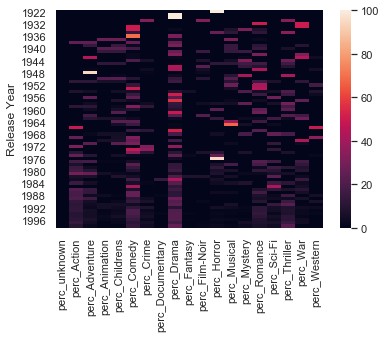

```python
sns.heatmap(final)
```

### 9. Find the top 25 movies according to average ratings such that each movie has number of ratings more than 100 - 10 marks

Hints :

1. Find the count of ratings and average ratings for every movie.
2. Slice the movies which have ratings more than 100.
3. Sort values according to average rating such that movie which highest rating is on top.
4. Select top 25 movies.
5. You will have to use the .merge() function to get the movie titles.

Note: This question will need you to research about groupby and apply your findings. You can find more on groupby on https://realpython.com/pandas-groupby/.

```python
top25 = complete_data.copy()
top25.head()
```

|  | user id | movie id | rating | timestamp | age | gender | occupation | zip code | movie title | release date | ... | Film-Noir | Horror | Musical | Mystery | Romance | Sci-Fi | Thriller | War | Western | Release Year |
| --- | --- | --- | --- | --- | --- | --- | --- | --- | --- | --- | --- | --- | --- | --- | --- | --- | --- | --- | --- | --- | --- |
| 0 | 196 | 242 | 3 | 881250949 | 49 | M | writer | 55105 | Kolya | 24-Jan-1997 | ... | 0 | 0 | 0 | 0 | 0 | 0 | 0 | 0 | 0 | 1997 |
| 1 | 305 | 242 | 5 | 886307828 | 23 | M | programmer | 94086 | Kolya | 24-Jan-1997 | ... | 0 | 0 | 0 | 0 | 0 | 0 | 0 | 0 | 0 | 1997 |
| 2 | 6 | 242 | 4 | 883268170 | 42 | M | executive | 98101 | Kolya | 24-Jan-1997 | ... | 0 | 0 | 0 | 0 | 0 | 0 | 0 | 0 | 0 | 1997 |
| 3 | 234 | 242 | 4 | 891033261 | 60 | M | retired | 94702 | Kolya | 24-Jan-1997 | ... | 0 | 0 | 0 | 0 | 0 | 0 | 0 | 0 | 0 | 1997 |
| 4 | 63 | 242 | 3 | 875747190 | 31 | M | marketing | 75240 | Kolya | 24-Jan-1997 | ... | 0 | 0 | 0 | 0 | 0 | 0 | 0 | 0 | 0 | 1997 |

5 rows × 30 columns

```python
count_ratings = top25.groupby('movie title').count()
count_ratings = count_ratings.reset_index()
```

```python
sum_ratings = top25.groupby('movie title').sum()
sum_ratings
```

| movie title | user id | movie id | rating | timestamp | age | unknown | Action | Adventure | Animation | Childrens | ... | Fantasy | Film-Noir | Horror | Musical | Mystery | Romance | Sci-Fi | Thriller | War | Western |
| --- | --- | --- | --- | --- | --- | --- | --- | --- | --- | --- | --- | --- | --- | --- | --- | --- | --- | --- | --- | --- | --- |
| 'Til There Was You | 3454 | 11700 | 21 | 7975036369 | 222 | 0 | 0 | 0 | 0 | 0 | ... | 0 | 0 | 0 | 0 | 0 | 9 | 0 | 0 | 0 | 0 |
| 1-900 | 2385 | 6765 | 13 | 4398629778 | 155 | 0 | 0 | 0 | 0 | 0 | ... | 0 | 0 | 0 | 0 | 0 | 5 | 0 | 0 | 0 | 0 |
| 101 Dalmatians | 49086 | 24525 | 317 | 96239159737 | 3535 | 0 | 0 | 0 | 0 | 109 | ... | 0 | 0 | 0 | 0 | 0 | 0 | 0 | 0 | 0 | 0 |
| 12 Angry Men | 56694 | 22250 | 543 | 110362033216 | 4398 | 0 | 0 | 0 | 0 | 0 | ... | 0 | 0 | 0 | 0 | 0 | 0 | 0 | 0 | 0 | 0 |
| 187 | 21201 | 13530 | 124 | 36285345927 | 1195 | 0 | 0 | 0 | 0 | 0 | ... | 0 | 0 | 0 | 0 | 0 | 0 | 0 | 0 | 0 | 0 |
| ... | ... | ... | ... | ... | ... | ... | ... | ... | ... | ... | ... | ... | ... | ... | ... | ... | ... | ... | ... | ... | ... |
| Young Guns | 46073 | 23432 | 324 | 89243223823 | 2848 | 0 | 101 | 0 | 0 | 0 | ... | 0 | 0 | 0 | 0 | 0 | 0 | 0 | 0 | 0 | 101 |
| Young Guns II | 22179 | 52272 | 122 | 38816163631 | 1116 | 0 | 44 | 0 | 0 | 0 | ... | 0 | 0 | 0 | 0 | 0 | 0 | 0 | 0 | 0 | 44 |
| Young Poisoner's Handbook, The | 18552 | 22427 | 137 | 36167894707 | 1312 | 0 | 0 | 0 | 0 | 0 | ... | 0 | 0 | 0 | 0 | 0 | 0 | 0 | 0 | 0 | 0 |
| Zeus and Roxanne | 3197 | 6984 | 13 | 5265202530 | 243 | 0 | 0 | 0 | 0 | 6 | ... | 0 | 0 | 0 | 0 | 0 | 0 | 0 | 0 | 0 | 0 |
| Á köldum klaka (Cold Fever) | 655 | 1633 | 3 | 889331315 | 50 | 0 | 0 | 0 | 0 | 0 | ... | 0 | 0 | 0 | 0 | 0 | 0 | 0 | 0 | 0 | 0 |

1658 rows × 24 columns

```python
new = pd.DataFrame(
    {'movie title': count_ratings['movie title'].values,
     'Num Ratings': count_ratings['rating'].values,
     'Sum Ratings': sum_ratings['rating'].values

    }
)
new
```

|  | movie title | Num Ratings | Sum Ratings |
| --- | --- | --- | --- |
| 0 | 'Til There Was You | 9 | 21 |
| 1 | 1-900 | 5 | 13 |
| 2 | 101 Dalmatians | 109 | 317 |
| 3 | 12 Angry Men | 125 | 543 |
| 4 | 187 | 41 | 124 |
| ... | ... | ... | ... |
| 1653 | Young Guns | 101 | 324 |
| 1654 | Young Guns II | 44 | 122 |
| 1655 | Young Poisoner's Handbook, The | 41 | 137 |
| 1656 | Zeus and Roxanne | 6 | 13 |
| 1657 | Á köldum klaka (Cold Fever) | 1 | 3 |

1658 rows × 3 columns

```python
new['Avg Rating'] = new['Sum Ratings']/new['Num Ratings']
pop_movies = new[new['Num Ratings'] > 100]
pop_movies.head()
```

|  | movie title | Num Ratings | Sum Ratings | Avg Rating |
| --- | --- | --- | --- | --- |
| 2 | 101 Dalmatians | 109 | 317 | 2.908257 |
| 3 | 12 Angry Men | 125 | 543 | 4.344000 |
| 7 | 2001: A Space Odyssey | 259 | 1028 | 3.969112 |
| 15 | Absolute Power | 127 | 428 | 3.370079 |
| 16 | Abyss, The | 151 | 542 | 3.589404 |

```python
pop_movies = pop_movies.sort_values(by=['Avg Rating'], ascending = False)
pop_movies.head()
```

|  | movie title | Num Ratings | Sum Ratings | Avg Rating |
| --- | --- | --- | --- | --- |
| 317 | Close Shave, A | 112 | 503 | 4.491071 |
| 1278 | Schindler's List | 298 | 1331 | 4.466443 |
| 1647 | Wrong Trousers, The | 118 | 527 | 4.466102 |
| 272 | Casablanca | 243 | 1083 | 4.456790 |
| 1313 | Shawshank Redemption, The | 283 | 1258 | 4.445230 |

```python
top25_movies = pop_movies['movie title'].head(25)
top25_movies
```

```
317                                       Close Shave, A
1278                                    Schindler's List
1647                                 Wrong Trousers, The
272                                           Casablanca
1313                           Shawshank Redemption, The
1214                                         Rear Window
1567                                 Usual Suspects, The
1394                                           Star Wars
3                                           12 Angry Men
302                                         Citizen Kane
1502                               To Kill a Mockingbird
1101                     One Flew Over the Cuckoo's Nest
1325                           Silence of the Lambs, The
1076                                  North by Northwest
611                                       Godfather, The
1292                                      Secrets & Lies
620                                    Good Will Hunting
935                            Manchurian Candidate, The
432     Dr. Strangelove or: How I Learned to Stop Worr...
1204                             Raiders of the Lost Ark
1575                                             Vertigo
1495                                             Titanic
850                                   Lawrence of Arabia
925                                  Maltese Falcon, The
455                             Empire Strikes Back, The
Name: movie title, dtype: object
```